# 2.3 Using Percent Slope to Determine Tree Height

Notice that by walking farther from the tree (having a longer run), Tobias’ slope readings were smaller than Georgia’s , even though they both ended up with the same height. The angles at which Tobias was looking at the tree were smaller.

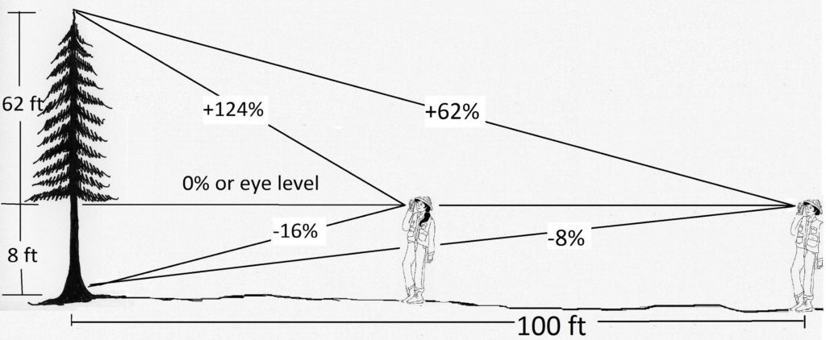

Figure 2.5. A tree can be measured from any distance, but the farther back one is from the tree, the less foreshortened the view, and generally, the more accurate the slope readings.

Also notice that when Tobias walked out 100 feet from the tree, his run equaled the denominator, 100, cancelling it out and leaving the tree equal to the readings from the clinometers. This “shortcut” makes it much easier and faster to determine tree height by reducing the number of conversions that have to be made.

(62+8) = 70 or 70 feet

What happens at a horizontal distance of 150 feet? The slope readings are even smaller.

Thus, the farther one walks from a tree, the better the perspective for seeing the tree top. Being too close to the tree can result in an obscured top, as side branches will be in the way (Figures 2.6 and 2.7).

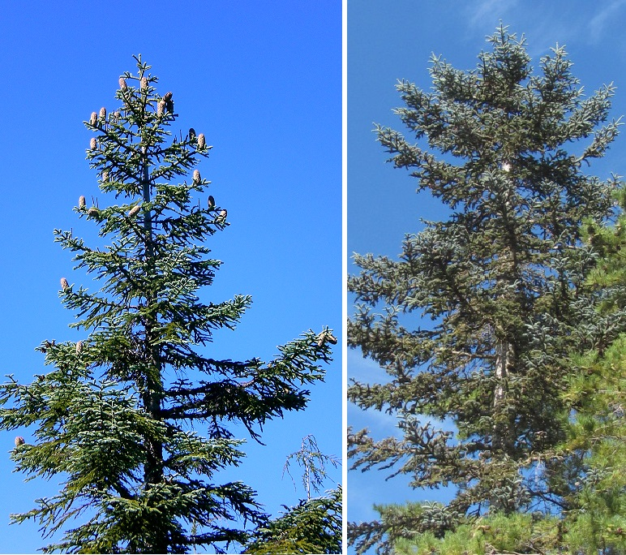

Figure 2.6. Tree top is seen clearly on the left, but side branches obscure the true tree top on the right.

In the photo on the left, the tree’s top can be seen clearly. The tip is distinguishable from the top side branches. The right photo however, illustrates a foreshortened view of the top where side branches could be mistaken for the top. If a %slope reading is taken on side branches thought to be the true top, the tree’s height can be overestimated as shown in Figure 2.7.

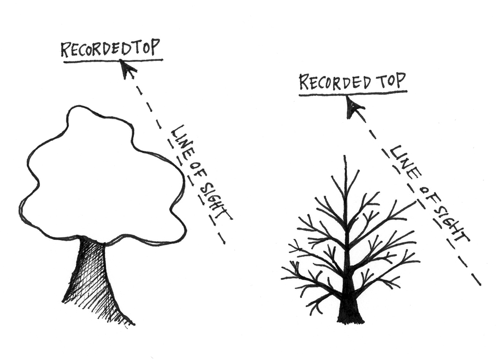

Figure 2.7. Examples of height measurement error from sighting on a side branch thought to be the top, on both a hardwood and a conifer. Height is overestimated.

## License

[Forest Measurements](https://openoregon.pressbooks.pub/forestmeasurements) Copyright © 2016 by Joan DeYoung is licensed under a [Creative Commons Attribution 4.0 International License](https://creativecommons.org/licenses/by/4.0/), except where otherwise noted.